# Lab 5: Publishing Content with Leaflet

## 1.4 Prep Files

[Features To JSON—Conversion toolbox | ArcGIS for Desktop](https://pro.arcgis.com/en/pro-app/tool-reference/conversion/features-to-json.htm)

```r
ogrDrivers()
```

```
##              name write
## 1      AeronavFAA FALSE
## 2          ARCGEN FALSE
## 3          AVCBin FALSE
## 4          AVCE00 FALSE
## 5             BNA  TRUE
## 6             CSV  TRUE
## 7             DGN  TRUE
## 8             DXF  TRUE
## 9          EDIGEO FALSE
## 10 ESRI Shapefile  TRUE
## 11     Geoconcept  TRUE
## 12        GeoJSON  TRUE
## 13       Geomedia FALSE
## 14         GeoRSS  TRUE
```

[output cut: 35 more lines]

GeoJSON

```r
library(rgdal) # Geospatial Data Abstraction Library (GDAL) for R

gdb = 'H:/esm296-4f/lab3/golf.gdb'
dir = 'H:/esm296-4f/lab5_online/adv-gis/data'

# iterate through features in geodatabase
for (fc in ogrListLayers(gdb)){

  # print paths
  geo = sprintf('%s/%s.geojson', dir, fc)
  tmp = tempfile()
  cat(sprintf('gdb/fc: %s/%s\n  -> tmp: %s\n  -> geo: %s\n', gdb, fc, tmp, geo))

  # read in feature class
  sp = readOGR(gdb, fc)

  # output to geojson
  writeOGR(sp, dsn=tmp, layer='dummy', driver='GeoJSON')

  # move file
  file.rename(tmp, geo)
}
```

```
## gdb/fc: H:/esm296-4f/lab3/golf.gdb/cart_paths
##   -> tmp: C:\Users\BBEST_~1.ESM\AppData\Local\Temp\Rtmp6Pxo3f\file1de43771291d
##   -> geo: H:/esm296-4f/lab5_online/adv-gis/data/cart_paths.geojson
## gdb/fc: H:/esm296-4f/lab3/golf.gdb/pts_tree
##   -> tmp: C:\Users\BBEST_~1.ESM\AppData\Local\Temp\Rtmp6Pxo3f\file1de41880a88
##   -> geo: H:/esm296-4f/lab5_online/adv-gis/data/pts_tree.geojson
## gdb/fc: H:/esm296-4f/lab3/golf.gdb/lns_cart
##   -> tmp: C:\Users\BBEST_~1.ESM\AppData\Local\Temp\Rtmp6Pxo3f\file1de43b481496
##   -> geo: H:/esm296-4f/lab5_online/adv-gis/data/lns_cart.geojson
## gdb/fc: H:/esm296-4f/lab3/golf.gdb/plys_bunker
##   -> tmp: C:\Users\BBEST_~1.ESM\AppData\Local\Temp\Rtmp6Pxo3f\file1de42e47f85
##   -> geo: H:/esm296-4f/lab5_online/adv-gis/data/plys_bunker.geojson
```

check your output folder (ie `dir` in above script)

2. Get to see how Github renders GeoJSON

## 1.5 Get polygons of bristlecone pine distribution

Let’s continuing with our pet organism the bristlecone pine (*Pinus longaeva*). Download the species distribution shapefile from this website:

- [USGS GECSC: Tree Species Distribution Maps for North America](http://esp.cr.usgs.gov/data/little/)

Unzip and create directories as needed so the shapefile and associated files live at this exact path:

```
H:\esm296-4f\lab5\raw\pinulong.shp
```

## 1.6 4. Generate points of bristlecone pine and create GeoJSON files

Let’s also get observation points of bristlecone pine to provide another type of vector data to display.

Copy the following scripts into RStudio and save to your lab5 homework location, ie `H:\esm296-4f\github\lab5`:

- [`get_species.R`](https://github.com/ucsb-bren/esm296-4f/blob/gh-pages/wk4/get_species.R) pulls points from GBIF and outputs a shapefile
- [`create_geojson.R`](https://github.com/ucsb-bren/esm296-4f/blob/gh-pages/wk5/create_geojson.R) converts shapefile of points and polygons into GeoJSON

Change the input variable USER to your Github username for the second script and run both in sequence so you should then have the following:

- `H:\esm296-4f\lab5\raw\`
- `pinulong.shp` - polygon shapefile
- `pts_pinulong.shp` - point shapefile
- `H:\esm296-4f\bbest.github.io\map\`
- `ply_pinulong.geojson` - polygon GeoJSON file
- `pts_pinulong.geojson` - points GeoJSON file

Push these scripts in `H:\esm296-4f\github\lab5` to your Github site.

## 1.7 5. Open website files in RStudio and push GeoJSON files

Let’s use RStudio to push these created GeoJSON files and edit the HTML of the site. Go to File > New Project… > Existing Directory. Navigate to your H:296-4f.github.io folder. I recommend not opening this in a new window to reduce confusion.

You should see in your Git pane the “map” folder containing the GeoJSON files and other two files created by the new RStudio project listed as untracked status.

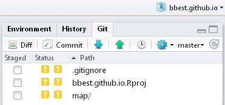

Check all of these to add, commit and push to your repository. Now visit your Github site https://github.com/USER/USER.github.io and navigate to the *.geojson files in your map directory.

You should see the points and polygons automatically rendered by Github in a little zoomable map with clickable popups showing the given feature’s attributes. Pretty cool!

## 1.8 6. Create Leaflet Mapper

But what about embedding these maps in your own website? And how about combining the points and polygons into a single map view?

To do this, we’ll use the same Javascript library as Github: [Leaflet.js](http://leafletjs.com). Let’s put this in a simple URL on your website USER.github.io/map. By default web servers generally serve up an index.html for any given folder. So copy the index.html in the root of your site into a new map folder. To do this in RStudio’s Files pane, after creating New Folder map, tick index.html, More > Copy… `map/index.html`.

Now click on map/index.html > Open in Editor.

Let’s fix the link to the stylesheet which is now, relative to the map folder, one directory up. While we’re at it, let’s add the stylesheet and script needed for Leaflet.

Replace this line:

```html
<link rel="stylesheet" type="text/css" media="screen" href="stylesheets/stylesheet.css">
```

with these:

```html
<link rel="stylesheet" href="../stylesheets/stylesheet.css">
<link rel="stylesheet" href="../stylesheets/leaflet.awesome-markers.css">
<!--link rel="stylesheet" href="http://cdn.leafletjs.com/leaflet-0.7.3/leaflet.css" /-->
<link rel="stylesheet" href="http://cdn.leafletjs.com/leaflet/v0.7.7/leaflet.css" />
<!--link rel="stylesheet" href="http://maxcdn.bootstrapcdn.com/font-awesome/4.2.0/css/font-awesome.min.css" -->
<!--link rel="stylesheet" href="https://maxcdn.bootstrapcdn.com/font-awesome/4.5.0/css/font-awesome.min.css" -->
<!--link href="http://maxcdn.bootstrapcdn.com/font-awesome/4.5.0/css/font-awesome.min.css" rel="stylesheet" integrity="sha256-3dkvEK0WLHRJ7/Csr0BZjAWxERc5WH7bdeUya2aXxdU= sha512-+L4yy6FRcDGbXJ9mPG8MT/3UCDzwR9gPeyFNMCtInsol++5m3bk2bXWKdZjvybmohrAsn3Ua5x8gfLnbE1YkOg==" crossorigin="anonymous"-->

<!--script src="http://cdn.leafletjs.com/leaflet-0.7.3/leaflet.js"></script-->
<script src="http://cdn.leafletjs.com/leaflet/v0.7.7/leaflet.js"></script>
<script src="http://calvinmetcalf.github.io/leaflet-ajax/dist/leaflet.ajax.min.js"></script>
<script src="http://cdnjs.cloudflare.com/ajax/libs/Leaflet.awesome-markers/2.0.0/leaflet.awesome-markers.js"></script>
```

Then in the body of the HTML, replace the contents of whatever is in between the following, ie `...`:

```html
    <!-- MAIN CONTENT -->
    <div id="main_content_wrap" class="outer">
      <section id="main_content" class="inner">

...

      </section>
    </div>

    <!-- FOOTER  -->
```

And within the `...` above, insert the following:

```html
<div id="map" style="width: 800px; height: 600px"></div>

<script>
  // create Leaflet map object and set view's center and zoom level
  var map = L.map('map').setView([38, -115], 7);

  // add background map layer
  var Esri_NatGeoWorldMap = L.tileLayer(
    'http://server.arcgisonline.com/ArcGIS/rest/services/NatGeo_World_Map/MapServer/tile/{z}/{y}/{x}');
  Esri_NatGeoWorldMap.addTo(map)
</script>
```

```javascript
// add geojson of points
var pts = new L.GeoJSON.AJAX('./pts_pinulong.geojson');
pts.addTo(map)

// add GeoJSON of points
var ply = new L.GeoJSON.AJAX('./ply_pinulong.geojson');
ply.addTo(map)
```

Next, let’s customize the symbology so the points are green tree markers and polygons are orange.

We’re going to use the Leaflet.awesome-markers which enables you to use any of the nifty icons from [Font-Awesome](http://fortawesome.github.io/Font-Awesome/icons/). To use this library we need to add some files zip prepped for you in this zip file you should download it to directly inside your `H:\esm296-4f\USER.github.io` folder:

Leaflet.awesome-markers_files.7z

Open it in 7-zip so you can see the files. Go ahead and right click on 7-zip > Extract Here to place the files in the necessary folders.

Replace the lines you last added above in map/index.html adding geojson points and polygons with these enanced versions:

```javascript
// create tree marker
var treeMarker = L.AwesomeMarkers.icon({
  icon: 'tree',
  prefix: 'fa',
  markerColor: 'darkgreen',
  iconColor: 'white'});

// add geojson points with tree marker and popup
var pts = new L.GeoJSON.AJAX('./pts_pinulong.geojson', {
  pointToLayer: function (feature, latlng) {
    return L.marker(latlng, {icon: treeMarker});
  },
  onEachFeature: function (feature, layer) {
    layer.bindPopup(
      "Collected by: <strong>" + feature.properties.collctr + "</strong><br><br>" +
      "at: " + feature.properties.localty + "<br><br>" +
      "for: " + feature.properties.instttn, { maxWidth: 200 });
  }
});
pts.addTo(map)

// add geojson polygons with a style
var ply = new L.GeoJSON.AJAX('./ply_pinulong.geojson', {
  "color": "#ff7800",
  "weight": 5,
  "opacity": 0.65 });
ply.addTo(map)
```

# 2 Create Website to Host Map

## 2.1 Sign up for Github

Setup a free user account by visiting github.com.

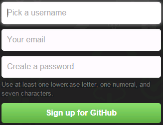

Pick any untaken username (you can [change your username later](https://help.github.com/articles/changing-your-github-username)), use a *.edu email (for quicker approval later of educational discount) and set a password. Choose the free account.

## 2.2 Create Repository

[Create a new repository](https://help.github.com/articles/creating-a-new-repository) called `adv-gis` at Github.com, presuming you are logged into the site. Yes, Initialize this repository with a README.

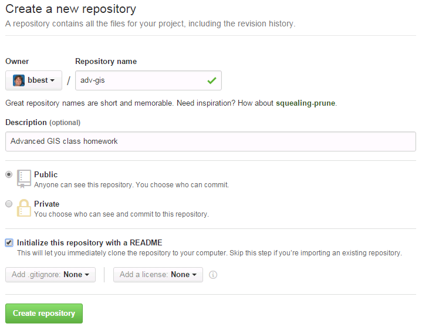

Now go to your repository Settings (upper right of navigation), and click on the Automatic page generator.

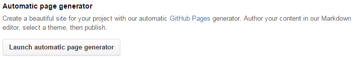

Clear the Body and enter the heading level 3 text `### Map` like so:

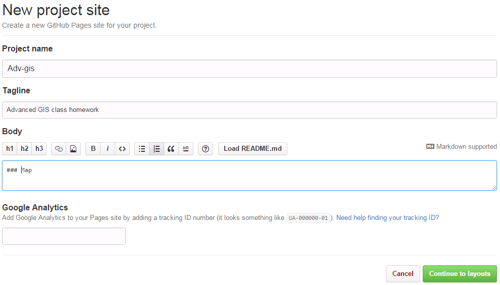

Continue to layouts. Have fun choosing a layout aligned with your aesthetic sensibilities and Publish page.

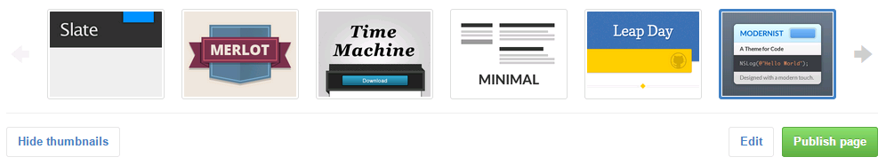

This creates a new branch (ie an alternate set of files) called “gh-pages”. Let’s make this the default branch by going to Settings (upper right), Branches (left), and select “gh-pages” from the drop-down to switch it from “master”. Click Update. Accept the warning, and click “I understand, update the default branch.”

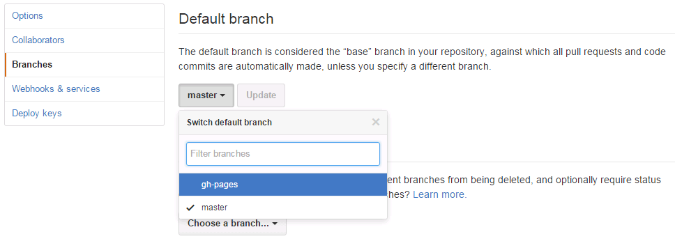

Now click on Code. You’ll notice some web files now in your repository: images, javascripts, stylesheets, and index.html. (The params.json is used internally for the automatic page generator.)

Now Edit your Description to add the URL https://USER.github.io/adv-gis (replacing USER with your Github username) to the Website entry at top next to Description and Save

[figure not shown]

Finally, check out your website! (Might take up to 10 minutes to appear)

## 2.3 Clone Repository Locally with RStudio

To copy the contents of the repository to your local machine is to “clone” it. Let’s use RStudio to do this. Open RStudio, navigate to menu Tools, and confirm RStudio knows to find the git executable at `C:/Program Files/Git/bin/git.exe`.

[figure not shown]

Navigate to menu File, New Project. Select Version Control, Git. Enter the URL of your repository and select an output location.

[figure not shown]

## 2.4 7. Add link from main site

To add a link from your root site USER.github.io, let’s add a link from the index.html there to map/index.html.

```html
<h1>Welcome</h1>

Check out my <strong><a href='./map'>map of bristlecone pine</a></strong>.
```

# Next Steps (optional)

The possibilities with Github are vast, but here at least are a few tips on next steps to get the most out of using Github.

## 2.5 Create your Personal Website

Create a new repository named `username.github.io` (where `username` is replaced with your Github username). Tick the box to Initialize this repository with a README. You can use the Automatic page generator (under Settings) like the lab to initialize web content which will be viewable at http://username.github.io. For more help, see [pages.github.com](https://pages.github.com/).

## 2.7 Get Free Private Repositories through Educational Discount

I recommend you also request the Github Educational Discount at education.github.com.

This signup will enable you to have free private repositories. Select Student, Individual account. You’ll need to provide some sort of image confirming your student status. I took a screen shot of an email verifying my enrollment. You shouldn’t see this note about a school-issued email address if you used your *.edu email. For “How do you plan to use Github”, something like: “I’ll be using a private repo to turn in assignments for a graduate level course on Advanced Topics in GIS (at the request of instructor @bbest). Hope to feel the stoke of playing with this trending tech!”

Usually only takes a couple days to grant you the [Micro plan](https://github.com/pricing) giving you 7 private repositories free of charge.

# Further Resources

- [GeoJSON.io](http://geojson.io) - powerful GeoJSON interface, allowing editing of features and tables directly from Github
- [Leaflet Providers](http://leaflet-extras.github.io/leaflet-providers/preview/) - copy & paste a whole slew of pretty background layers into your map, like Stamen.watercolor
- [Leaflet Tutorials](http://leafletjs.com/examples.html) - go deeper into Leaflet capabilities here
- [Mapping geoJSON files on GitHub](https://help.github.com/articles/mapping-geojson-files-on-github/) - more background on Github capabilities, including symbology, embedding and clustering
- [R and Leaflet: leafletR package](http://zevross.com/blog/2014/04/11/using-r-to-quickly-create-an-interactive-online-map-using-the-leafletr-package/)
- [GDAL.org GeoJSON Driver](http://www.gdal.org/drv_geojson.html)
- [Leaflet Awesome Markers](https://github.com/lvoogdt/Leaflet.awesome-markers)
- [Create a Leaflet map using QGIS: qgis2leaf plugin](http://zevross.com/blog/2014/08/05/it-is-incredibly-easy-to-create-a-leaflet-map-using-qgis/)
- [GDAL Leaflet tile maker for rasters](http://www.gdal.org/gdal2tiles.html)
- [Stream GeoJSON at Github directly into QGIS](http://blog.geomusings.com/2013/06/18/geojson-on-github-now-what/)